# Exploring the BRFSS data

## Setup

### Load packages

```r
library(ggplot2)
library(dplyr)
```

## load data

```r
load("brfss2013.RData")
```

## The Behavioral Risk Factor Surveillance System (BRFSS) - 2013

###### Background

From [BRFSS Overview](http://www.cdc.gov/brfss/annual_data/2013/pdf/Overview_2013.pdf)

The Behavioral Risk Factor Surveillance System (BRFSS) is a collaborative project between all of the states in the United States (US) and participating US territories and the Centers for Disease Control and Prevention (CDC). The BRFSS is administered and supported by CDC’s Population Health Surveillance Branch, under the Division of Population Health at the National Center for Chronic Disease Prevention and Health Promotion. BRFSS is an ongoing surveillance system designed to measure behavioral risk factors for the non-institutionalized adult population (18 years of age and older) residing in the US. The BRFSS was initiated in 1984, with 15 states collecting surveillance data on risk behaviors through monthly telephone interviews. Over time, the number of states participating in the survey increased; by 2001, 50 states, the District of Columbia, Puerto Rico, Guam, and the US Virgin Islands were participating in the BRFSS. Today, all 50 states, the District of Columbia, Puerto Rico, and Guam collect data annually and American Samoa, Federated States of Micronesia, and Palau collect survey data over a limited point- in-time (usually one to three months). In this document, the term “state” is used to refer to all areas participating in BRFSS, including the District of Columbia, Guam, and the Commonwealth of Puerto Rico.

The BRFSS objective is to collect uniform, state-specific data on preventive health practices and risk behaviors that are linked to chronic diseases, injuries, and preventable infectious diseases that affect the adult population. Factors assessed by the BRFSS in 2013 include tobacco use, HIV/AIDS knowledge and prevention, exercise, immunization, health status, healthy days - health-related quality of life, health care access, inadequate sleep, hypertension awareness, cholesterol awareness, chronic health conditions, alcohol consumption, fruits and vegetables consumption, arthritis burden, and seatbelt use. Since 2011, BRFSS conducts both landline telephone- and cellular telephone-based surveys. In conducting the BRFSS landline telephone survey, interviewers collect data from a randomly selected adult in a household. In conducting the cellular telephone version of the BRFSS questionnaire, interviewers collect data from an adult who participates by using a cellular telephone and resides in a private residence or college housing.

Health characteristics estimated from the BRFSS pertain to the non-institutionalized adult population, aged 18 years or older, who reside in the US. In 2013, additional question sets were included as optional modules to provide a measure for several childhood health and wellness indicators, including asthma prevalence for people aged 17 years or younger.

###### References

- BRFSS web site: http://www.cdc.gov/brfss/
- BRFSS Questionnaire (Mandatory and Optional Modules): http://www.cdc.gov/brfss/questionnaires/pdf-ques/2013%20BRFSS_English.pdf
- BRFSS Codebook: http://www.cdc.gov/brfss/annual_data/2013/pdf/CODEBOOK13_LLCP.pdf
- BRFSS Guide to Calculated Variables: http://www.cdc.gov/brfss/annual_data/2013/pdf/2013_Calculated_Variables_Version15.pdf
- BRFSS Guide to Optional Modules Used, by State: http://apps.nccd.cdc.gov/BRFSSModules/ModByState.asp?Yr=2013

## Part 1: Data

Analysis of the data can be generalized since adults were randomly selected for the survey and also the sample is quite large.

Since the data is observational, only associative conclusion can be made though random sampling was used it is not appropriate to make causal conclusion since there can be some compounding variables. Causality is only great in experimental studies.

## Part 2: Research questions

**Research quesion 1:** Is risk behaviour such as binge drinking, smoking habits and seatbelt use prevalent among married, single or divorced individuals?

**Research quesion 2:** Is an overweight adult more likely to be hypertensive?

**Research quesion 3:** Is a physically active adult less likely to visit a doctor?

## Part 3: Exploratory data analysis

**Research quesion 1:**

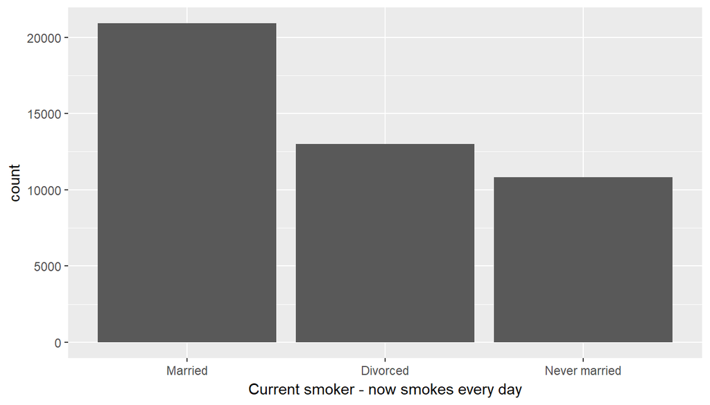

```r
#Summarize smoking habits based on marital status
brfss2013_marital <- brfss2013%>%
  filter(X_smoker3 %in% c("Current smoker - now smokes every day"))%>%
  filter(marital %in% c("Married","Divorced","Never married"))%>%
  mutate(seatbelt_use = ifelse(seatbelt =="Always","not risky","risky"))

brfss2013_marital%>%
  ggplot(aes(x = marital)) + geom_bar() + labs(x="Current smoker - now smokes every day")
```

This bar plot shows the number of adults that are current smokers categorized based on marital status. It can be seen that there are more married people that smoke.

```r
total <- length(brfss2013_marital$marital)
brfss2013_marital%>%
  group_by(marital)%>%
  summarise(prop = n()/total)
```

```
## # A tibble: 3 x 2
##   marital        prop
##   <fctr>        <dbl>
## 1 Married       0.467
## 2 Divorced      0.291
## 3 Never married 0.242
```

Summarises the proportion of current smokers.

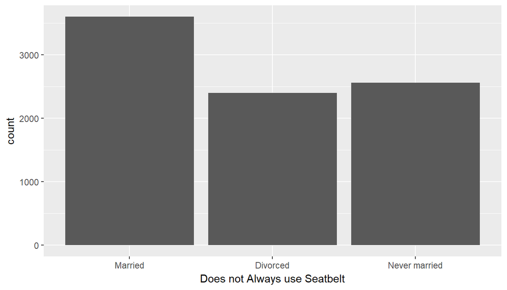

```r
# Summarize seat belt use based on marital status
total = length((brfss2013_marital %>%
 filter(seatbelt_use %in% c("risky")))$marital)

brfss2013_marital %>%
 filter(seatbelt_use %in% c("risky"))%>%
  ggplot(aes(x = marital)) +geom_bar() + labs(x="Does not Always use Seatbelt")
```

This bar plot shows the number of adults that do not always use seatbelt categorized based on marital status. It can be seen that more married adults do not always use their seatbelt. Two new levels, risky and not risky was defined for seatbelt use to separate adults that always use seatbelt from those that do not into two categoris.

```r
brfss2013_marital %>%
 filter(seatbelt_use %in% c("risky"))%>%
  group_by(marital)%>%
  summarise(prop = n()/total)
```

```
## # A tibble: 3 x 2
##   marital        prop
##   <fctr>        <dbl>
## 1 Married       0.421
## 2 Divorced      0.280
## 3 Never married 0.299
```

Summarises the proportion of seatbelt usage.

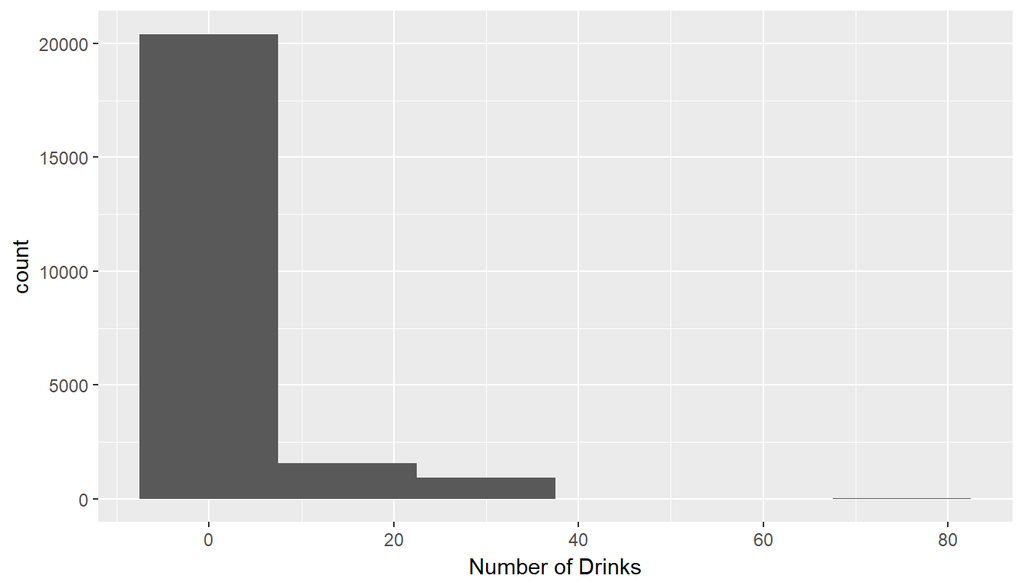

```r
# summarize drinking habits based on marital status
brfss2013_marital%>%
  filter(!is.na(drnk3ge5))%>%
ggplot(aes(x = drnk3ge5))+ geom_histogram(binwidth = 15) +labs(x="Number of Drinks")
```

This bar plot is a histogram that shows the distribution of binge drinking. It can be deduced that this distribution is right skewed.

```r
brfss2013_marital%>%
  filter(!is.na(drnk3ge5))%>%
  group_by(marital)%>%
  summarise(median=median(drnk3ge5),mean = mean(drnk3ge5), sd =sd(drnk3ge5),iqr=IQR(drnk3ge5), n = n())
```

```
## # A tibble: 3 x 6
##   marital       median  mean    sd   iqr     n
##   <fctr>         <dbl> <dbl> <dbl> <dbl> <int>
## 1 Married         0     2.47  5.95  2.00 10502
## 2 Divorced        0     3.17  7.07  3.00  6195
## 3 Never married   1.00  3.53  6.67  4.00  6188
```

**Research quesion 2:** To tackle this problem, I have to creat a contigency table for this two variables.

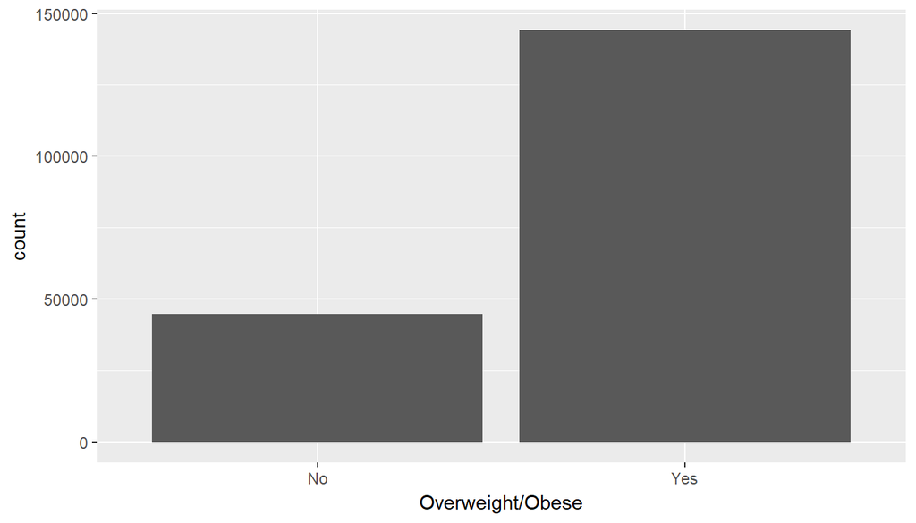

```r
brfss2013%>%
  filter(X_rfhype5 %in% c("Yes"))%>%
  filter(X_rfbmi5 %in% c("Yes","No"))%>%
  ggplot(aes(X_rfbmi5)) + geom_bar() + labs(x = "Overweight/Obese")
```

The plot suggests that overweight/obese adult are more likely to be hypertensive.

```r
ctable = table(brfss2013$X_rfbmi5,brfss2013$X_rfhype5)
prop.table(ctable)
```

```
##
##               No        Yes
##   No  0.25424346 0.09650845
##   Yes 0.33864498 0.31060311
```

Contingency Table Key:

Row: Obese/Overweight

Column: Hypertensive

From the contingency table it can be deduce that given an obese/overweight adult, there is ~47.8% chance that he/she is hypertensive.

**Research quesion 3:**

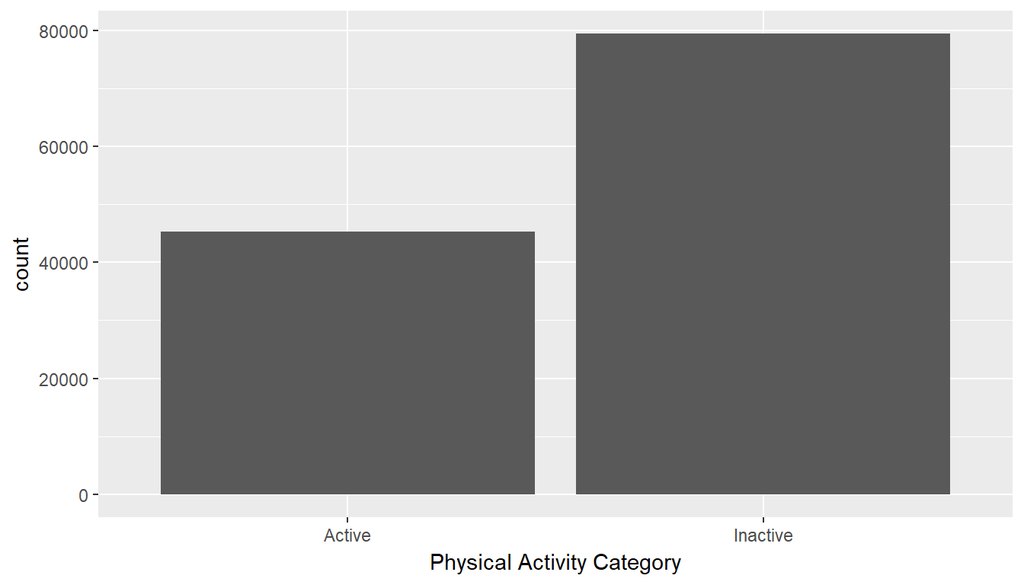

```r
brfss2013%>%
  filter(!is.na(drvisits), drvisits > 0)%>%
  filter(X_pacat1 %in% c("Inactive","Active"))%>%
  ggplot(aes(x = X_pacat1))+geom_bar() +labs(x ="Physical Activity Category")
```

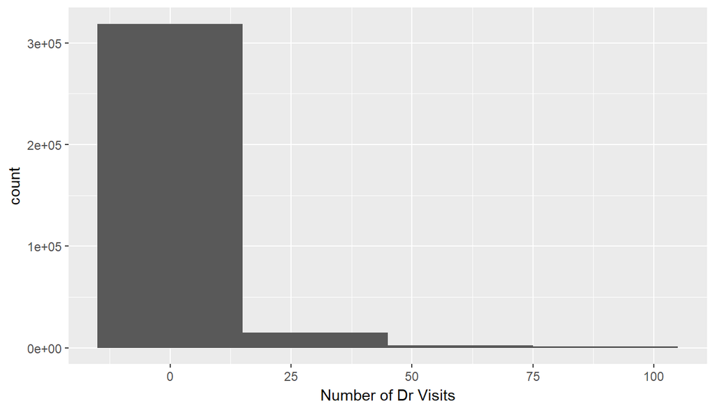

```r
brfss2013%>%
  filter(!is.na(drvisits))%>%
  ggplot(aes(x = drvisits))+geom_histogram(binwidth = 30) + labs(x="Number of Dr Visits", fig_cap="Stuff")
```

The plot shows that Doctor visits is right skewed lending the median to be the best measure of central tendency and interquartile range for variability.

```r
brfss2013%>%
  filter(!is.na(drvisits))%>%
summarise(median = median(drvisits),iqr = IQR(drvisits), n = n())
```

```
##   median iqr      n
## 1      3   5 337623
```